# Week 4 Quiz

1. For this quiz we will be using several R packages. R package versions change over time, the right answers have been checked using the following versions of the packages.
- AppliedPredictiveModeling: v1.1.6
- caret: v6.0.47
- ElemStatLearn: v2012.04-0
- pgmm: v1.1
- rpart: v4.1.8
- gbm: v2.1
- lubridate: v1.3.3
- forecast: v5.6
- e1071: v1.6.4

If you aren’t using these versions of the packages, your answers may not exactly match the right answer, but hopefully should be close.  
Load the vowel.train and vowel.test data sets:

```r
library(ElemStatLearn)
data(vowel.train)
data(vowel.test)
```

Set the variable y to be a factor variable in both the training and test set. Then set the seed to 33833. Fit (1) a random forest predictor relating the factor variable y to the remaining variables and (2) a boosted predictor using the “gbm” method. Fit these both with the train() command in the caret package.  
What are the accuracies for the two approaches on the test data set? What is the accuracy among the test set samples where the two methods agree?

```r
vowel.train$y <- as.factor(vowel.train$y)
vowel.test$y <- as.factor(vowel.test$y)
set.seed(33833)
Q1modRf <- train(y ~. , data = vowel.train, method = 'rf')
Q1modGbm <- train(y ~. , data = vowel.train, method = 'gbm', verbose = F)

Q1predRf <- predict(Q1modRf, newdata = vowel.test)
confusionMatrix(Q1predRf, vowel.test$y)$overall[1]
```

```
##  Accuracy
## 0.5887446
```

```r
Q1predGbm <- predict(Q1modGbm, newdata = vowel.test)
confusionMatrix(Q1predGbm, vowel.test$y)$overall[1]
```

```
## Accuracy
## 0.512987
```

```r
agree <- Q1predRf == Q1predGbm
confusionMatrix(vowel.test$y[agree], Q1predRf[agree])$overall[1]
```

```
## Accuracy
## 0.621118
```

```r
confusionMatrix(vowel.test$y[agree], Q1predGbm[agree])$overall[1]
```

```
## Accuracy
## 0.621118
```

```r
library(caret)
library(gbm)
set.seed(3433)
library(AppliedPredictiveModeling)
data(AlzheimerDisease)
adData = data.frame(diagnosis,predictors)
inTrain = createDataPartition(adData$diagnosis, p = 3/4)[[1]]
training = adData[ inTrain,]
testing = adData[-inTrain,]
```

```r
set.seed(62433)
Q2modRf <- train(diagnosis ~. , data = training, method = 'rf')
Q2modGbm <- train(diagnosis ~. , data = training, method = 'gbm', verbose = F)
Q2modLda <- train(diagnosis ~. , data = training, method = 'lda')

Q2predRf <- predict(Q2modRf, newdata = testing)
Q2predGbm <- predict(Q2modGbm, newdata = testing)
Q2predLda <- predict(Q2modLda, newdata = testing)

confusionMatrix(Q2predRf, testing$diagnosis)$overall[1]
```

```
##  Accuracy
## 0.7926829
```

```r
confusionMatrix(Q2predGbm, testing$diagnosis)$overall[1]
```

```
##  Accuracy
## 0.7804878
```

```r
confusionMatrix(Q2predLda, testing$diagnosis)$overall[1]
```

```
##  Accuracy
## 0.7682927
```

```r
Q2dataStack <- data.frame(Q2predRf, Q2predGbm, Q2predLda,
                          diagnosis = testing$diagnosis)
Q2modStack <- train(diagnosis ~., data = Q2dataStack, method = 'gam')
Q2predStack <- predict(Q2modStack, newdata = Q2dataStack)
confusionMatrix(Q2predStack, Q2dataStack$diagnosis)$overall[1]
```

```
## Accuracy
## 0.804878
```

```r
set.seed(3523)
library(AppliedPredictiveModeling)
data(concrete)
inTrain = createDataPartition(concrete$CompressiveStrength, p = 3/4)[[1]]
training = concrete[ inTrain,]
testing = concrete[-inTrain,]
```

Set the seed to 233 and fit a lasso model to predict Compressive Strength. Which variable is the last coefficient to be set to zero as the penalty increases? (Hint: it may be useful to look up ?plot.enet).

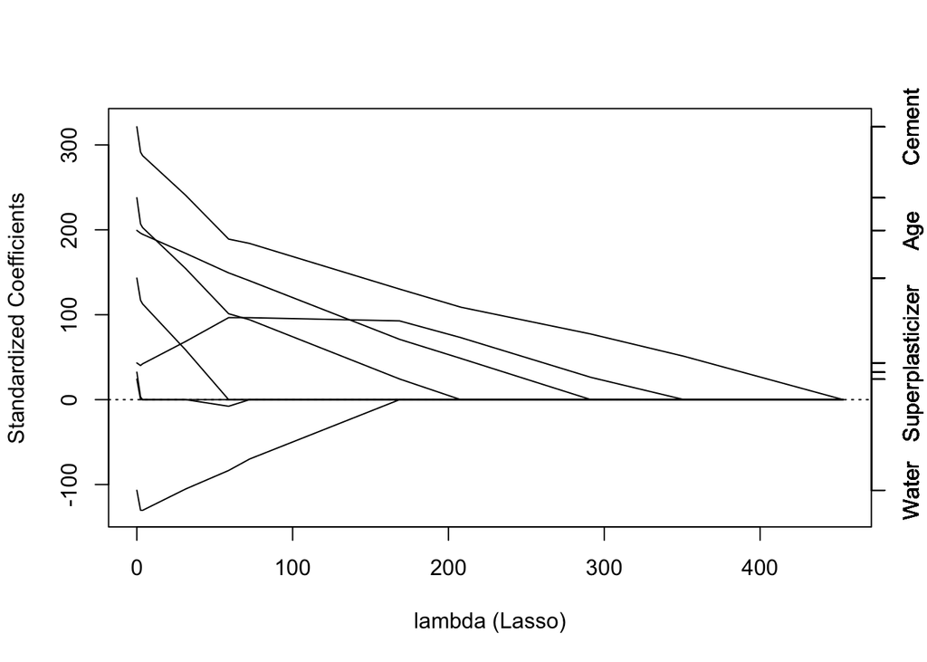

```r
set.seed(233)
Q3modLas <- train(CompressiveStrength ~., data = training, method = 'lasso')
library(elasticnet)
plot.enet(Q3modLas$finalModel, xvar = 'penalty')
```

- CoarseAggregate
- Age
- **Cement**
- Water
4. Load the data on the number of visitors to the instructors blog from [here](https://d396qusza40orc.cloudfront.net/predmachlearn/gaData.csv)  
   Using the commands:

```r
library(lubridate) # For year() function below
if (!file.exists('gaData.csv')) {
  download.file('https://d396qusza40orc.cloudfront.net/predmachlearn/gaData.csv',
                destfile = './gaData.csv',
                method = 'curl', quiet = T)
}
dat = read.csv("gaData.csv")
training = dat[year(dat$date) < 2012,]
testing = dat[(year(dat$date)) > 2011,]
tstrain = ts(training$visitsTumblr)
```

Fit a model using the bats() function in the forecast package to the training time series. Then forecast this model for the remaining time points. For how many of the testing points is the true value within the 95% prediction interval bounds?

```r
library(forecast)
Q4modFc <- bats(training$visitsTumblr)
fcast <- forecast(Q4modFc, h = nrow(testing), level = 0.95)
accuracy(fcast, testing$visitsTumblr)
```

```
##                     ME     RMSE       MAE      MPE   MAPE      MASE
## Training set  10.49059 258.7813  40.17169     -Inf    Inf 0.8425522
## Test set     174.66089 294.9901 199.92648 22.73707 40.045 4.1932146
##                    ACF1
## Training set 0.01240395
## Test set             NA
```

```r
(sum((fcast$lower < testing$visitsTumblr) & (fcast$upper > testing$visitsTumblr)))/nrow(testing)
```

```
## [1] 0.9617021
```

- 95%
- 94%
- **96%**
- 93%
5. Load the concrete data with the commands:

```r
set.seed(3523)
library(AppliedPredictiveModeling)
data(concrete)
inTrain = createDataPartition(concrete$CompressiveStrength, p = 3/4)[[1]]
training = concrete[ inTrain,]
testing = concrete[-inTrain,]
```

Set the seed to 325 and fit a support vector machine using the e1071 package to predict Compressive Strength using the default settings. Predict on the testing set. What is the RMSE?

```r
library(e1071)
set.seed(325)
Q5modSvm <- svm(CompressiveStrength ~., data = training)
Q5predSvm <- predict(Q5modSvm, testing)
accuracy(Q5predSvm, testing$CompressiveStrength)
```

```
##                 ME     RMSE      MAE       MPE     MAPE
## Test set 0.1682863 6.715009 5.120835 -7.102348 19.27739
```

- 6.93
- 107.44
- **6.72**
- 35.59